# Capstone - Milestone report

martinvanelp

december 2015

# Abstract

The data sets for the Capstone project have been analysed, mostly with help of the tm-package. The general conclusion is that with rather few words, or groups of words, in a dictionary one can cover large parts of the written language in these data sets. More specifically, about 200 words can cover 50% of the words used in tweets according to this analysis. Lastly, I am pondering whether I should continue on this path, with the tm-package, or make my own, more slim, approach to the Capstone challenge.

# Downloading and loading the data

The table beneath shows some statistics on the different data sets for the English language. In the code it is possible to easily replace “en_US” with another available language. Using the tm-package I have been able to filter for profanity, based on https://gist.github.com/ryanlewis/a37739d710ccdb4b406d. The tm-package does create bulky data with its functions, which means I have only been able to analyze samples of each data set (n = 10000).

|  | Lines | MeanLength | LongestLine |
| --- | --- | --- | --- |
| blogs | 899288 | 230.0 | 40833 |
| news | 1010242 | 201.2 | 11384 |
| twitter | 2360148 | 68.8 | 213 |

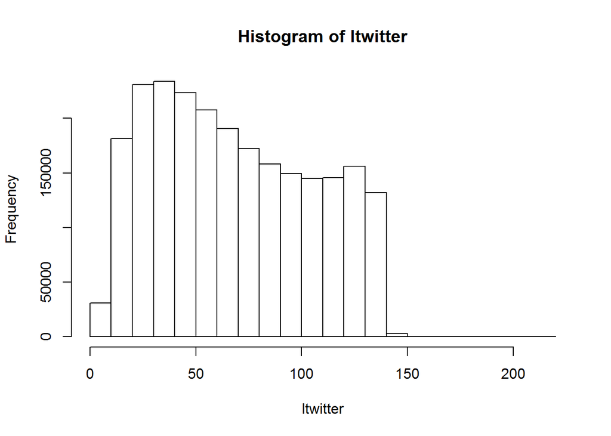

# Statistics and findings

Beneath are figures and tables for each data set (blogs, news, and twitter) for unigrams, bigrams and trigrams. For the unigrams the data sets have been cleaned for stopwords (frequent words like “is”, “the”, “and”).

The general conclusion based on the analyses of each data set is that rather few words are very common and that frequency of words quickly drops. Moreover, although there are differences many words are common in the blogs, news and twitter data sets.

## Explore blogs

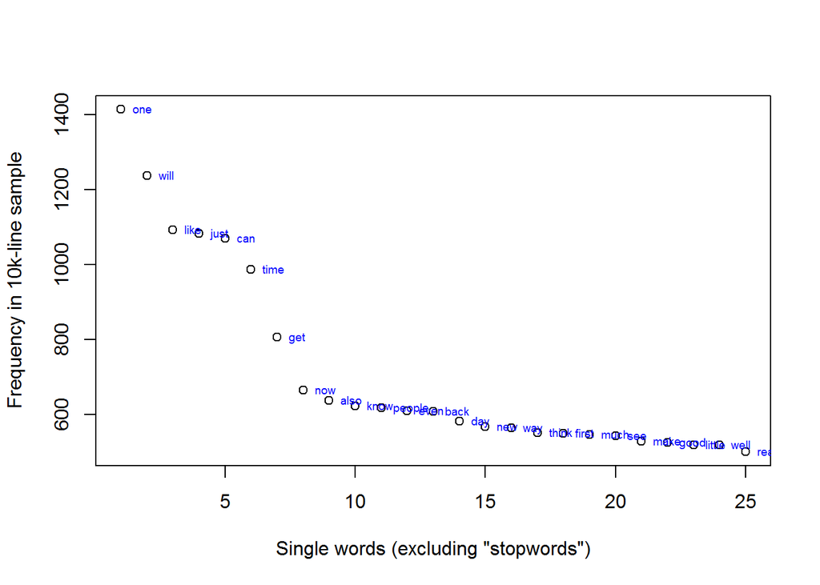

```
##        frequency
## one         1414
## will        1237
## like        1093
## just        1082
## can         1070
## time         986
## get          806
## now          665
## also         637
## know         623
## people       617
## even         610
## back         607
## day          581
## new          567
## way          563
## think        551
## first        549
## much         546
## see          542
## make         528
## good         525
## little       519
## well         518
## really       500
```

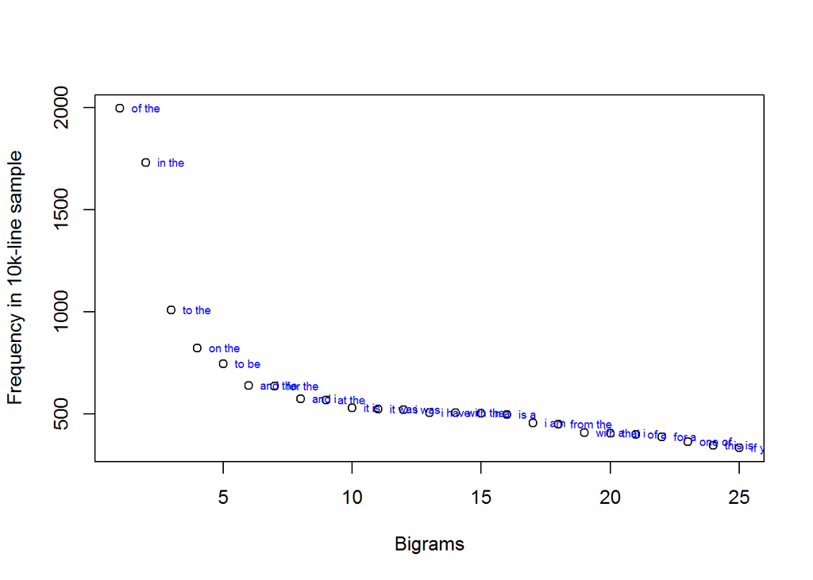

```
##          frequency
## of the        1995
## in the        1729
## to the        1010
## on the         822
## to be          747
## and the        641
## for the        638
## and i          574
## at the         570
## it is          531
## it was         524
## i was          522
## i have         508
## with the       506
## in a           504
## is a           498
## i am           457
## from the       451
## with a         409
## that i         407
## of a           402
## for a          388
## one of         366
## this is        347
## if you         335
```

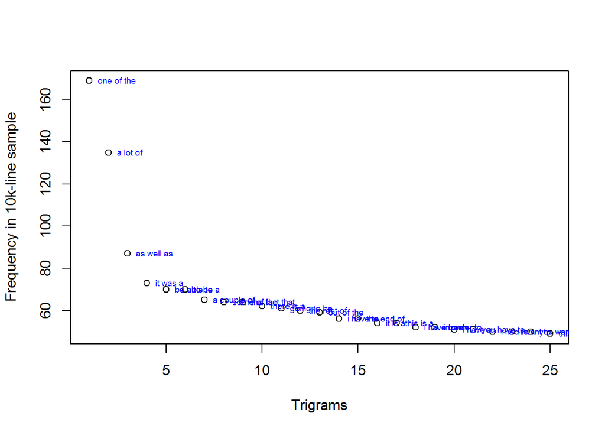

```
##               frequency
## one of the          169
## a lot of            135
## as well as           87
## it was a             73
## be able to           70
## to be a              70
## a couple of          65
## some of the          64
## the fact that        64
## there is a           62
## going to be          61
## the rest of          60
## out of the           59
## i have to            56
## the end of           56
## it is a              54
## this is a            54
## i have been          52
## in order to          52
## i have a             51
## you have to          51
## i had to             50
## i want to            50
## you want to          50
## this is the          49
```

## Explore news

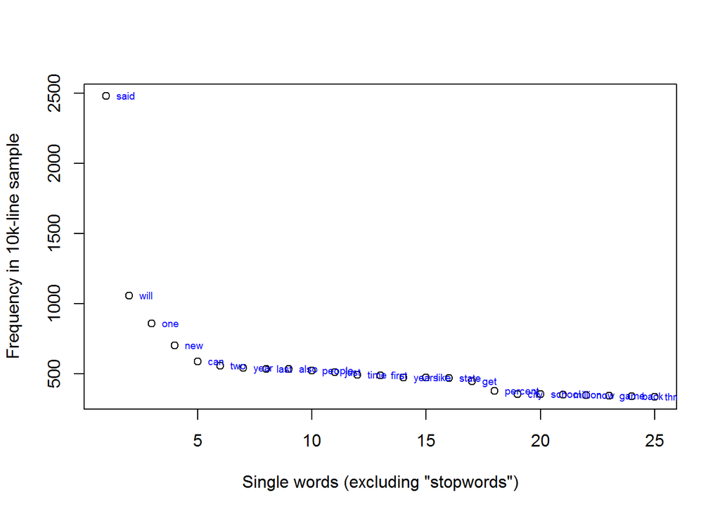

```
##         frequency
## said         2480
## will         1058
## one           861
## new           702
## can           589
## two           557
## year          541
## last          537
## also          535
## people        525
## just          511
## time          492
## first         491
## years         476
## like          474
## state         469
## get           446
## percent       377
## city          355
## school        355
## million       353
## now           349
## game          343
## back          342
## three         336
```

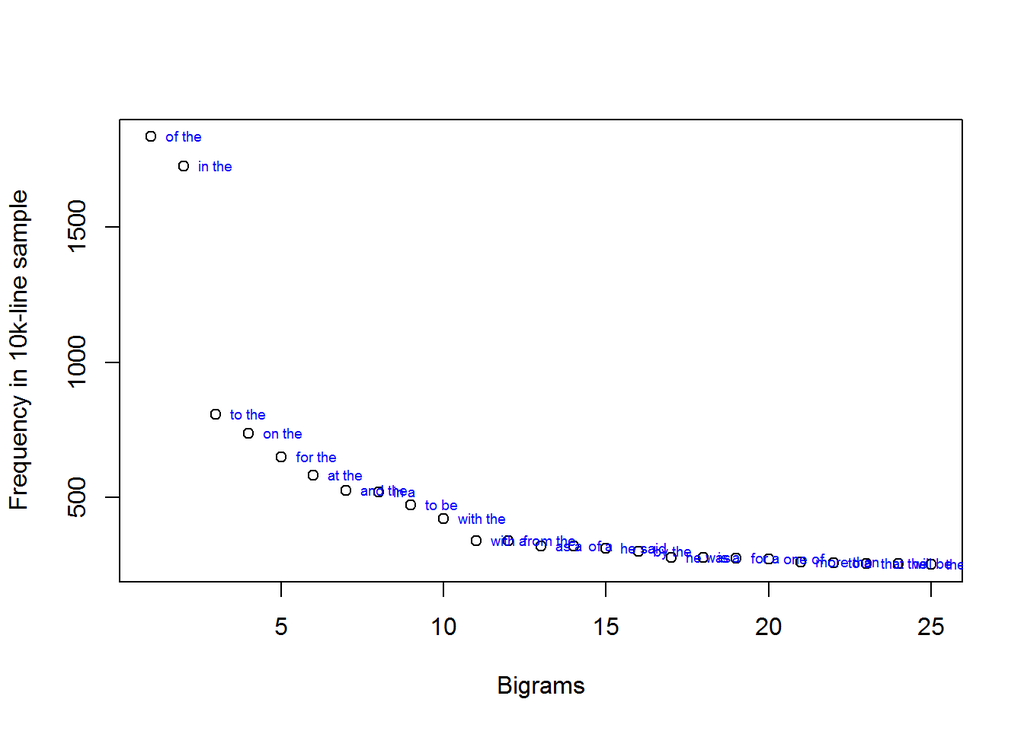

```
##           frequency
## of the         1836
## in the         1727
## to the          808
## on the          736
## for the         650
## at the          580
## and the         523
## in a            520
## to be           472
## with the        420
## with a          339
## from the        337
## as a            319
## of a            318
## he said         309
## by the          298
## he was          275
## is a            275
## for a           273
## one of          269
## more than       260
## to a            255
## that the        254
## will be         252
## the first       250
```

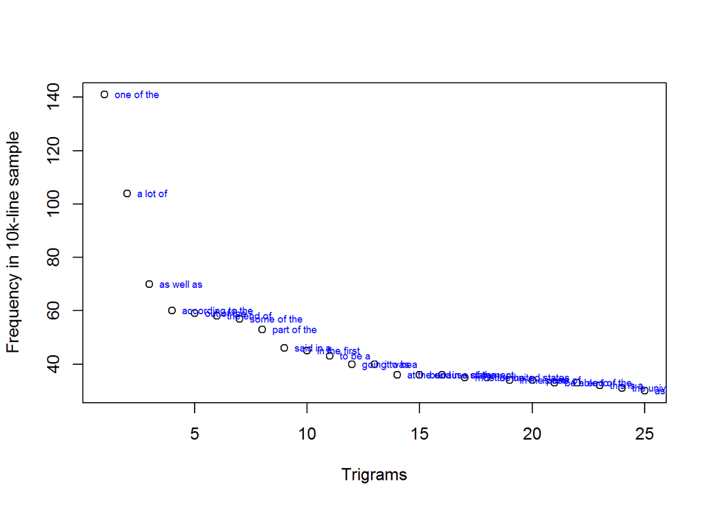

```
##                   frequency
## one of the              141
## a lot of                104
## as well as               70
## according to the         60
## out of the               59
## the end of               58
## some of the              57
## part of the              53
## said in a                46
## in the first             45
## to be a                  43
## going to be              40
## it was a                 40
## at the end               36
## because of the           36
## in a statement           36
## most of the              35
## the united states        35
## in the past              34
## is one of                34
## be able to               33
## end of the               33
## this is a                32
## the university of        31
## as part of               30
```

## Explore twitter

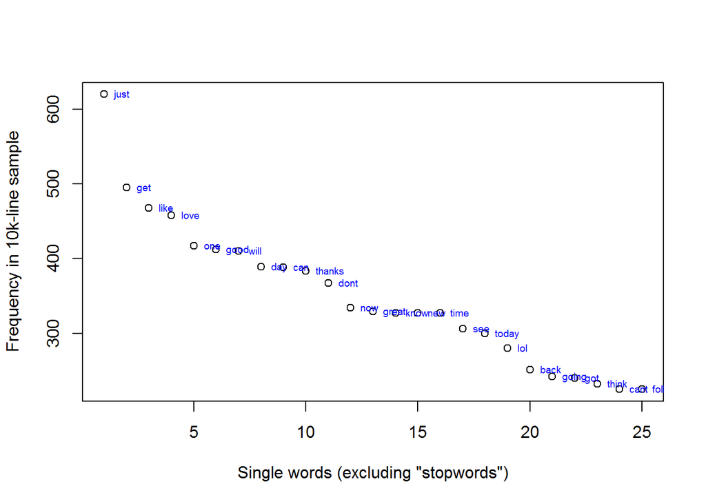

```
##        frequency
## just         620
## get          495
## like         468
## love         458
## one          417
## good         412
## will         410
## day          389
## can          388
## thanks       383
## dont         367
## now          334
## great        329
## know         327
## new          327
## time         327
## see          306
## today        300
## lol          280
## back         251
## going        242
## got          240
## think        232
## cant         225
## follow       225
```

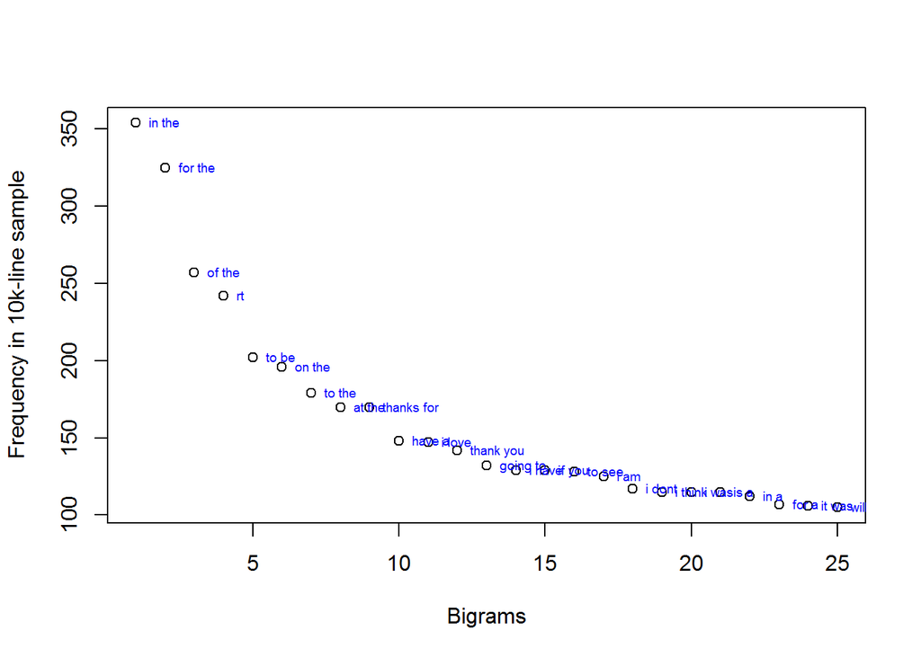

```
##            frequency
## in the           354
## for the          325
## of the           257
## rt               242
## to be            202
## on the           196
## to the           179
## at the           170
## thanks for       170
## have a           148
## i love           147
## thank you        142
## going to         132
## i have           129
## if you           129
## to see           128
## i am             125
## i dont           117
## i think          115
## i was            115
## is a             115
## in a             112
## for a            107
## it was           106
## will be          105
```

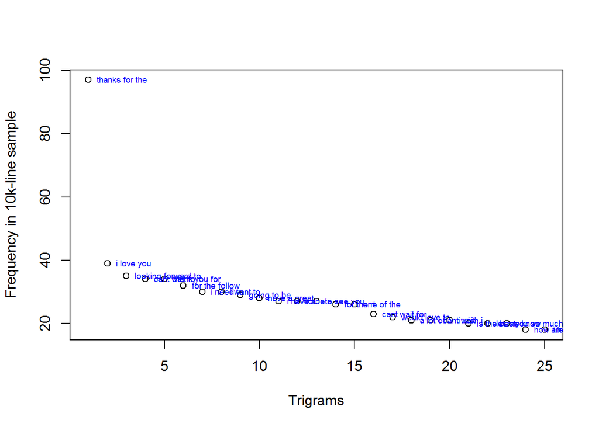

```
##                    frequency
## thanks for the            97
## i love you                39
## looking forward to        35
## cant wait to              34
## thank you for             34
## for the follow            32
## i need to                 30
## i want to                 30
## going to be               29
## have a great              28
## i have a                  27
## to be a                   27
## to see you                27
## for the rt                26
## one of the                26
## cant wait for             23
## would love to             22
## a lot of                  21
## i cant wait               21
## i wish i                  21
## is the best               20
## let me know               20
## you so much               20
## how are you               18
## i have to                 18
```

## Explore desirable dictionary size

In the twitter data I also explored how many unique words are needed to have 50% of all word instances in “twitter” language. Given the table beneath this is a little over two hundred, based on the aforementioned sample.

```
##         rank count cumulative  cumShare
## find     200    70      46924 0.4900730
## these    201    70      46994 0.4908041
## watch    202    70      47064 0.4915352
## check    203    69      47133 0.4922558
## excited  204    69      47202 0.4929764
## ready    205    69      47271 0.4936971
## already  206    68      47339 0.4944073
## coming   207    68      47407 0.4951174
## same     208    68      47475 0.4958276
## cool     209    67      47542 0.4965274
## having   210    67      47609 0.4972271
## house    211    67      47676 0.4979269
## god      212    66      47742 0.4986162
## long     213    66      47808 0.4993055
## play     214    66      47874 0.4999948
## wow      215    66      47940 0.5006841
## also     216    64      48004 0.5013525
## thought  217    63      48067 0.5020105
## while    218    63      48130 0.5026684
## until    219    62      48192 0.5033160
## done     220    61      48253 0.5039530
```

# Plan for prediction

Right now I am split between two options to build my prediction model:

1. build on top of the present analysis based in the tm-package, using the way that package tokenizes my data as predictors.
2. tokenize the data with a self-made method so I get more control of how tokens are created and what information is eventually available as predictors; I have some ideas on storing words as numbers and then using those numbers for a compact data set for prediction.

Clear from the exploratoy ranalysis is at least that in neither case many words/ngrams are needed to get some reasonable predictions. In favor of option 1 is that I already have some data cleaning and analysis set up. In favor of option 2 is that I can potentially create something without the tm-package that is less burdensome, and does not force me to use samples of data sets as above.